# Homework 3 - Forecasting Solar Power Production with ARIMA Models

Şirin Yağmur Abacı

2022-06-13

## 1 Introduction

The main purpose of this homework is to provide hourly solar power predictions of KIVANC 2 GES from 26 May 2022 to 3 June 2022, by using the production data given two days prior. Every day the actual hourly solar power production data is updated, and the appropriate forecasting is done for the next day.

In this homework, three different models are examined, which are ARIMA modeling for separate hours, SARIMA model for the whole time series assuming frequency of 24 hours and SARIMA model for the whole time series using the most correlated DSWRF value with the production (i.e. single location) as a regressor.

## 2 ARIMA Modeling for Separate Hours

Before starting with this model, the time series plots of the separate hours are plotted below. The hour indexes go from 0 to 23. At first, given data is manipulated into the desired form. There were also some missing data points, which are eliminated by the pad() function.

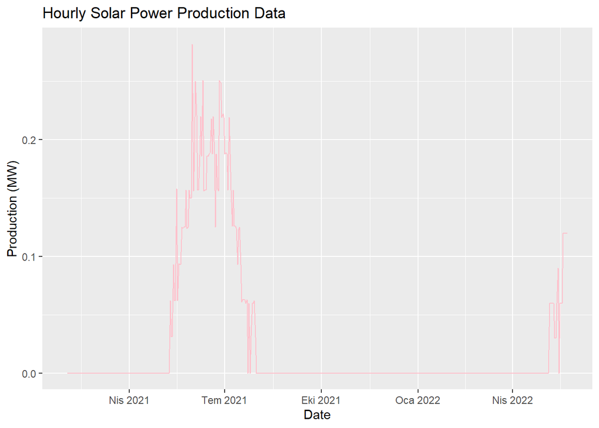

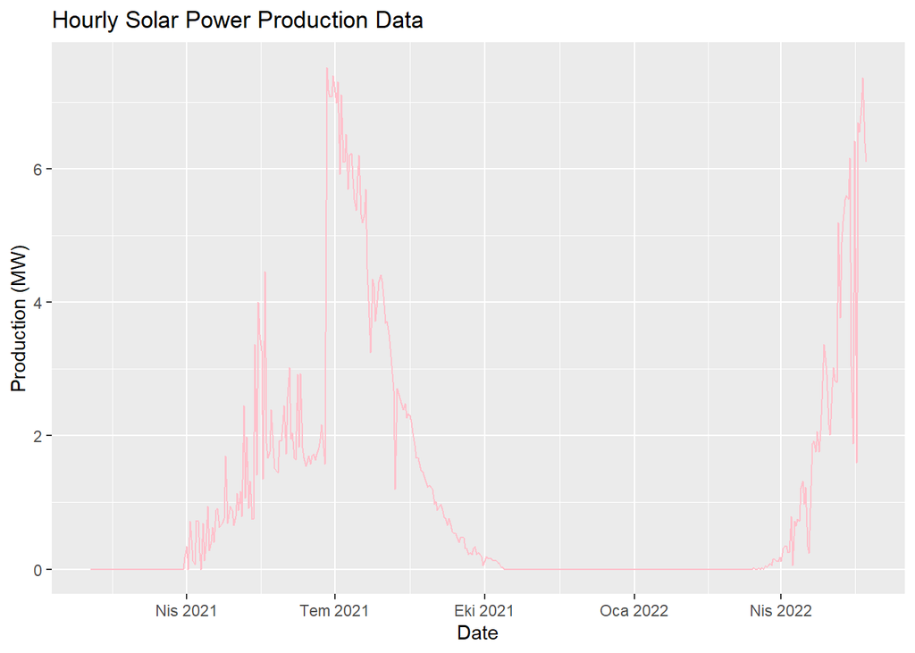

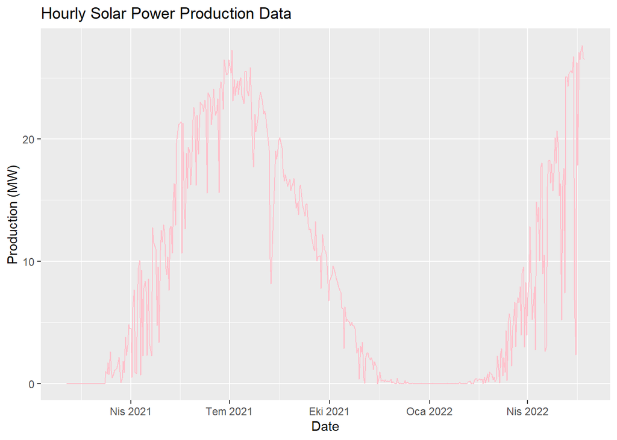

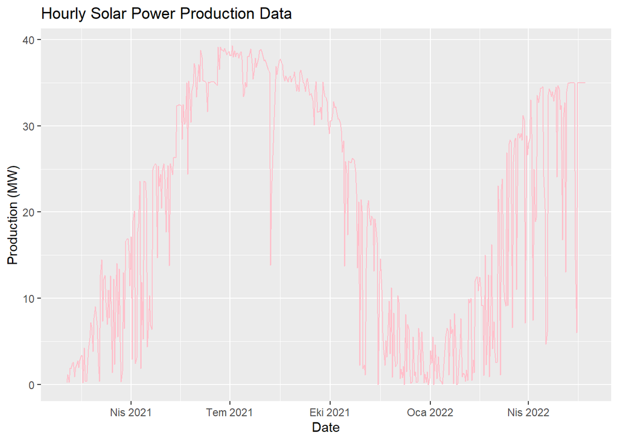

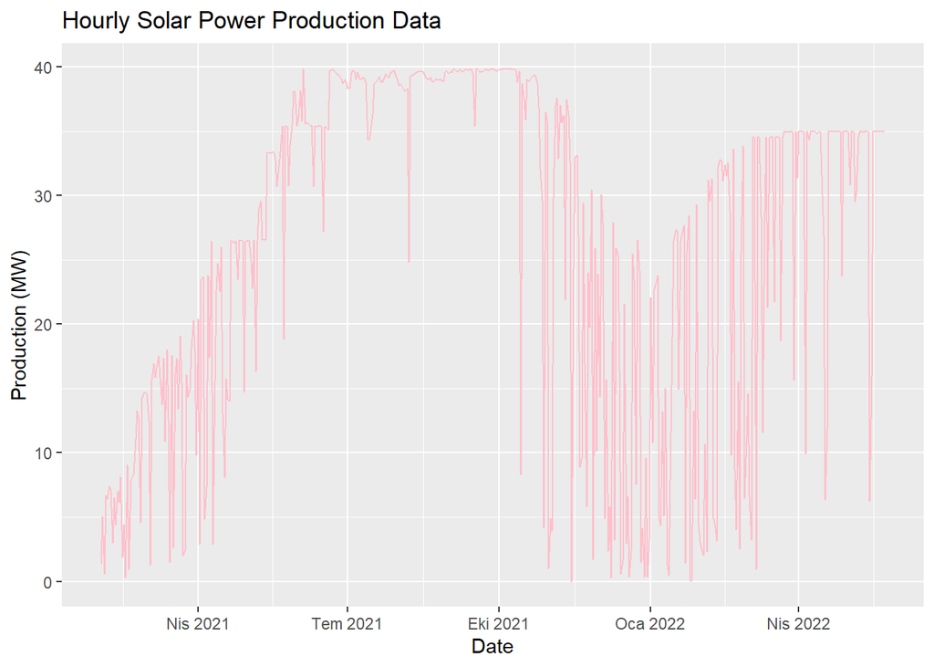

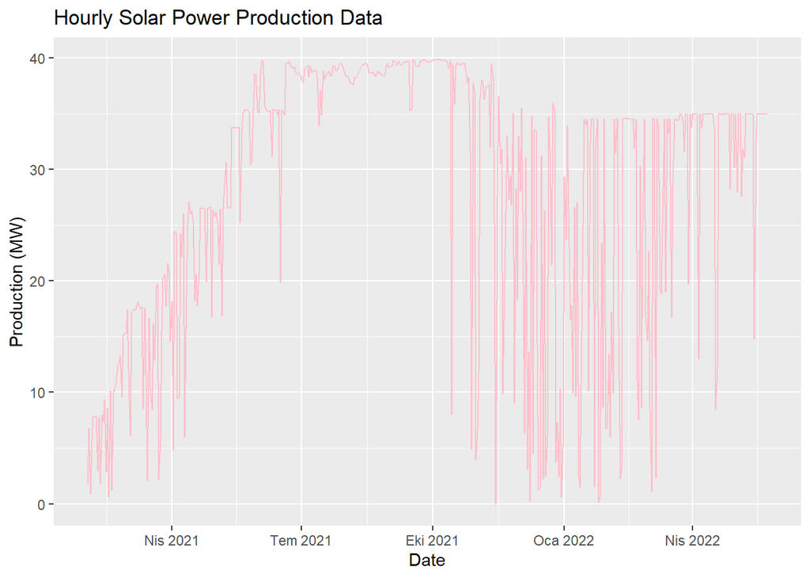

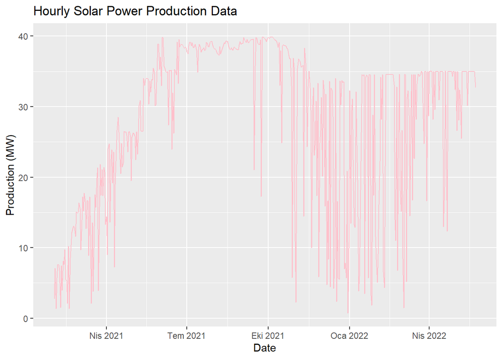

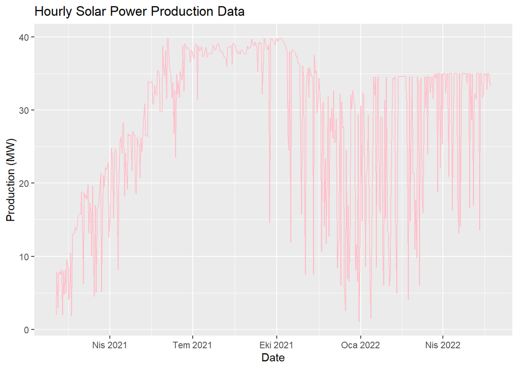

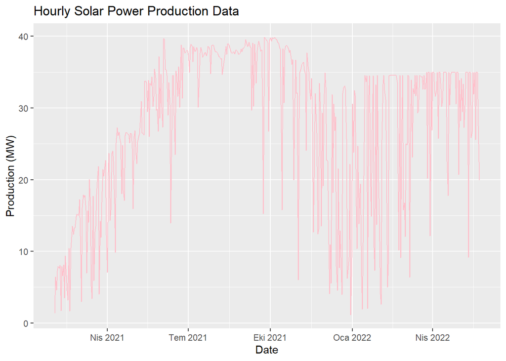

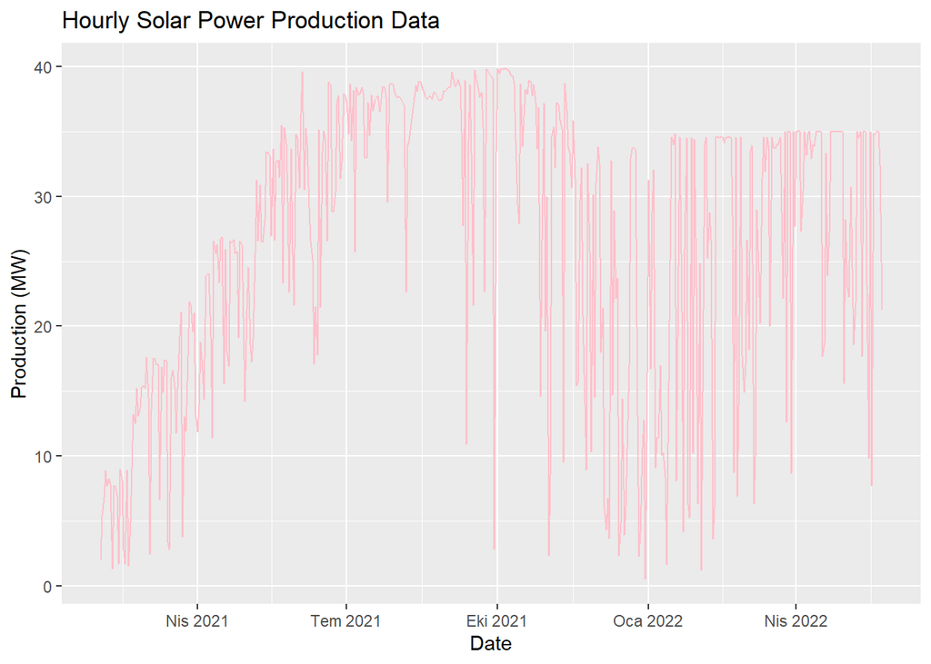

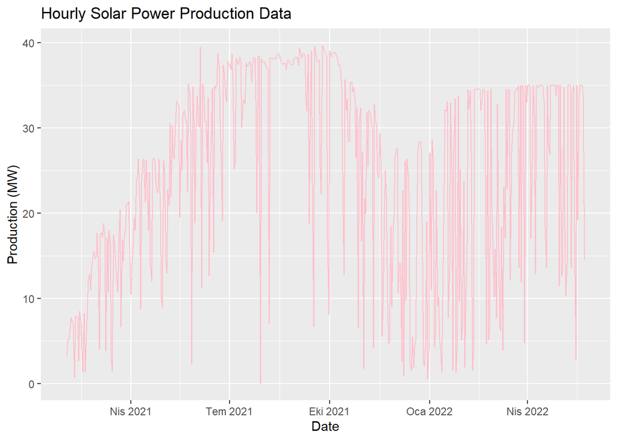

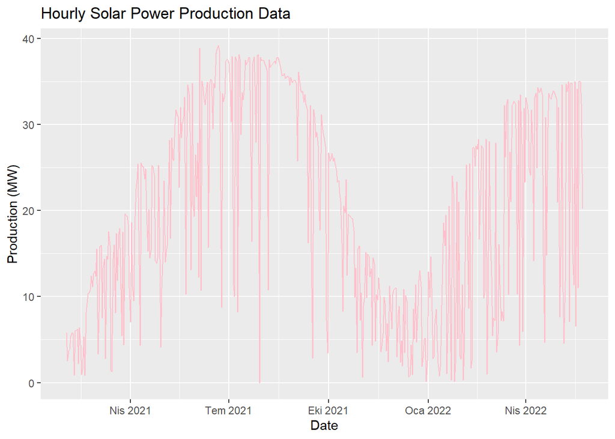

[4 more figures not shown]

As it can be seen in the graphs above, hours 0,1,2,3,4 and 21,22,23 are always zero. That is why I did not include them in this model, but instead I assigned zero to those values. For the other plots, it can be said that most of them deviate over time, meaning they are probably not stationary and will need further transformations. With this in mind, the hourly datas are converted into extended time series format and the corresponding ACF and PACF plots are given below.

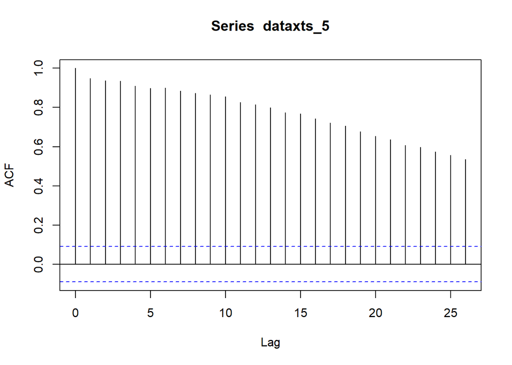

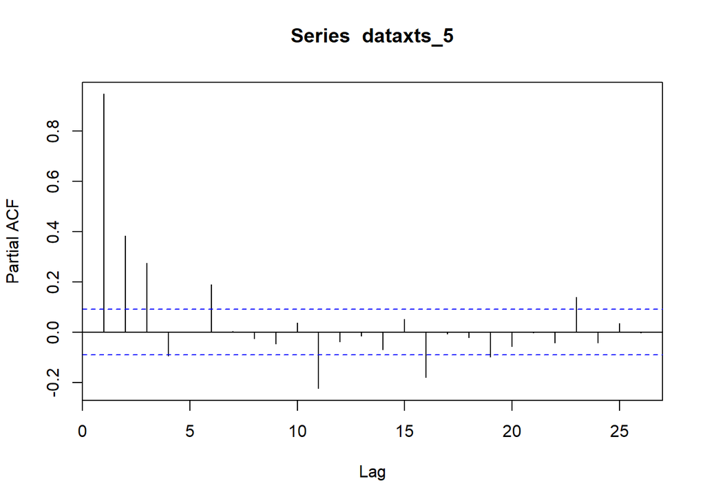

```
##
## #######################
## # KPSS Unit Root Test #
## #######################
##
## Test is of type: mu with 5 lags.
##
## Value of test-statistic is: 1.108
##
## Critical value for a significance level of:
##                 10pct  5pct 2.5pct  1pct
## critical values 0.347 0.463  0.574 0.739
```

```
##
## #######################
## # KPSS Unit Root Test #
## #######################
##
## Test is of type: mu with 5 lags.
##
## Value of test-statistic is: 1.106
##
## Critical value for a significance level of:
##                 10pct  5pct 2.5pct  1pct
## critical values 0.347 0.463  0.574 0.739
```

```
##
## #######################
## # KPSS Unit Root Test #
## #######################
##
## Test is of type: mu with 5 lags.
##
## Value of test-statistic is: 0.1576
##
## Critical value for a significance level of:
##                 10pct  5pct 2.5pct  1pct
## critical values 0.347 0.463  0.574 0.739
```

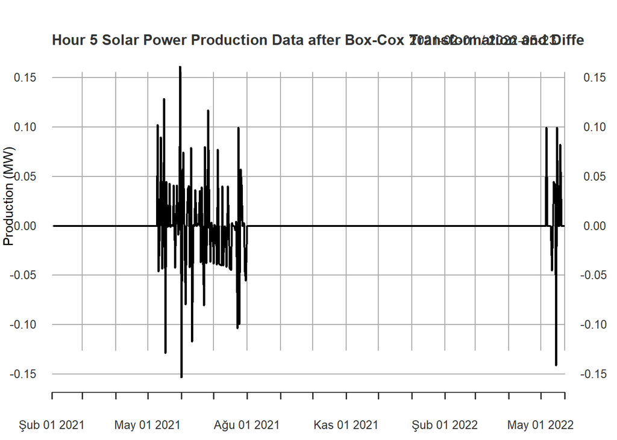

```
##
##  Fitting models using approximations to speed things up...
##
##  ARIMA(2,1,2) with drift         : -2234.997
##  ARIMA(0,1,0) with drift         : -2101.096
##  ARIMA(1,1,0) with drift         : -2191.456
##  ARIMA(0,1,1) with drift         : -2217.797
##  ARIMA(0,1,0)                    : -2103.006
##  ARIMA(1,1,2) with drift         : -2216.272
##  ARIMA(2,1,1) with drift         : -2231.318
##  ARIMA(3,1,2) with drift         : -2236.644
##  ARIMA(3,1,1) with drift         : -2229.127
##  ARIMA(4,1,2) with drift         : -2249.552
##  ARIMA(4,1,1) with drift         : -2227.695
##  ARIMA(5,1,2) with drift         : -2246.744
##  ARIMA(4,1,3) with drift         : -2247.707
##  ARIMA(3,1,3) with drift         : -2240.685
##  ARIMA(5,1,1) with drift         : -2237.022
##  ARIMA(5,1,3) with drift         : -2247.496
##  ARIMA(4,1,2)                    : -2251.12
##  ARIMA(3,1,2)                    : -2238.375
##  ARIMA(4,1,1)                    : -2229.275
##  ARIMA(5,1,2)                    : -2248.412
##  ARIMA(4,1,3)                    : -2249.328
##  ARIMA(3,1,1)                    : -2230.773
##  ARIMA(3,1,3)                    : -2242.293
##  ARIMA(5,1,1)                    : -2238.564
##  ARIMA(5,1,3)                    : -2249.061
##
##  Now re-fitting the best model(s) without approximations...
##
##  ARIMA(4,1,2)                    : -2260.519
##
##  Best model: ARIMA(4,1,2)
```

```
## Series: box_5
## ARIMA(4,1,2)
##
## Coefficients:
##           ar1      ar2      ar3      ar4      ma1     ma2
##       -0.3291  -1.0668  -0.3974  -0.3173  -0.2008  0.9659
## s.e.   0.0469   0.0474   0.0478   0.0446   0.0221  0.0233
##
## sigma^2 = 0.0004672:  log likelihood = 1137.38
## AIC=-2260.76   AICc=-2260.52   BIC=-2231.69
```

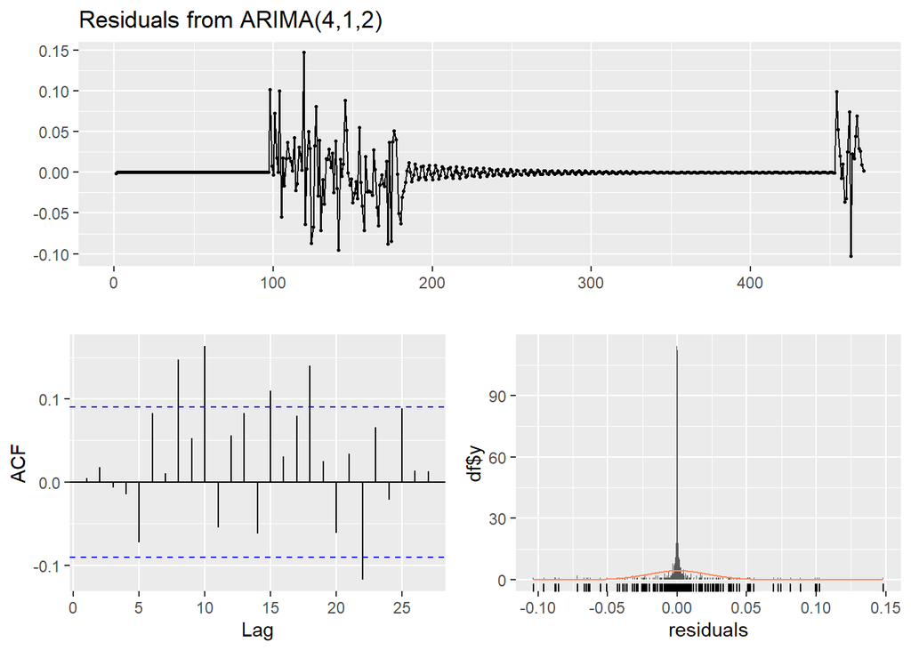

```
##
##  Ljung-Box test
##
## data:  Residuals from ARIMA(4,1,2)
## Q* = 30.814, df = 4, p-value = 3.34e-06
##
## Model df: 6.   Total lags used: 10
```

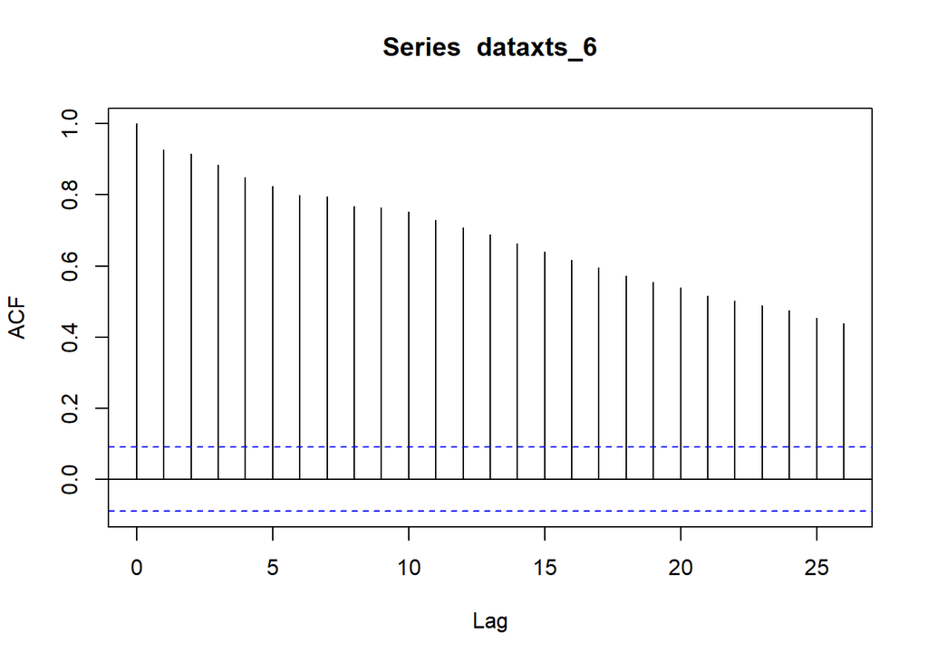

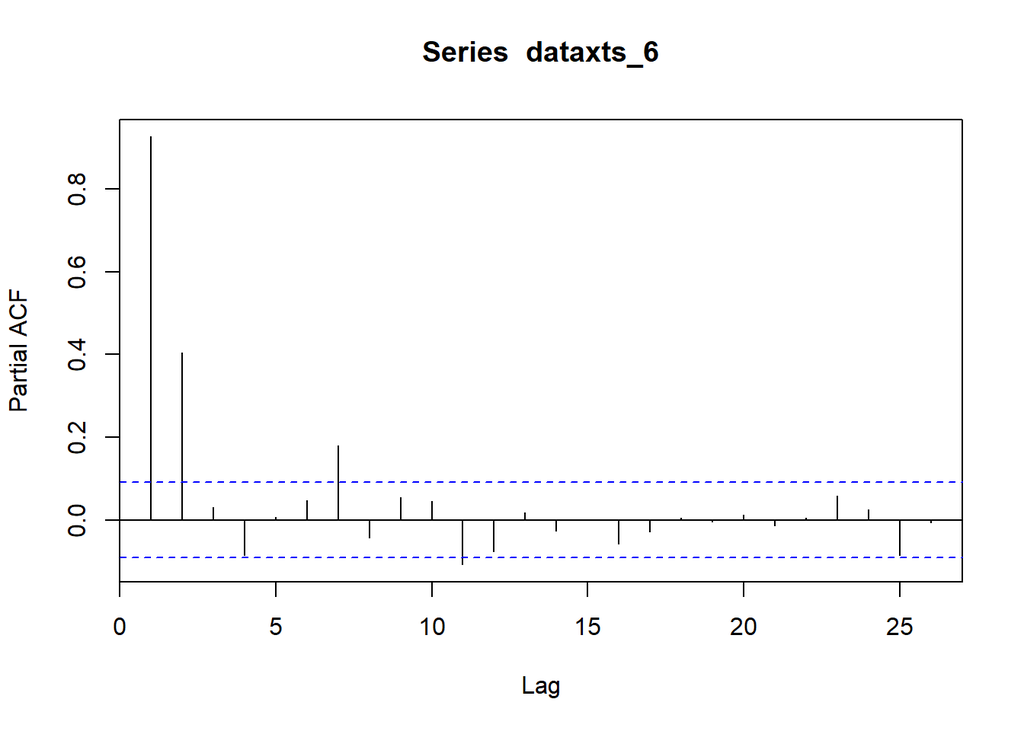

```
##
## #######################
## # KPSS Unit Root Test #
## #######################
##
## Test is of type: mu with 5 lags.
##
## Value of test-statistic is: 0.6682
##
## Critical value for a significance level of:
##                 10pct  5pct 2.5pct  1pct
## critical values 0.347 0.463  0.574 0.739
```

```
##
## #######################
## # KPSS Unit Root Test #
## #######################
##
## Test is of type: mu with 5 lags.
##
## Value of test-statistic is: 1.0808
##
## Critical value for a significance level of:
##                 10pct  5pct 2.5pct  1pct
## critical values 0.347 0.463  0.574 0.739
```

```
##
## #######################
## # KPSS Unit Root Test #
## #######################
##
## Test is of type: mu with 5 lags.
##
## Value of test-statistic is: 0.235
##
## Critical value for a significance level of:
##                 10pct  5pct 2.5pct  1pct
## critical values 0.347 0.463  0.574 0.739
```

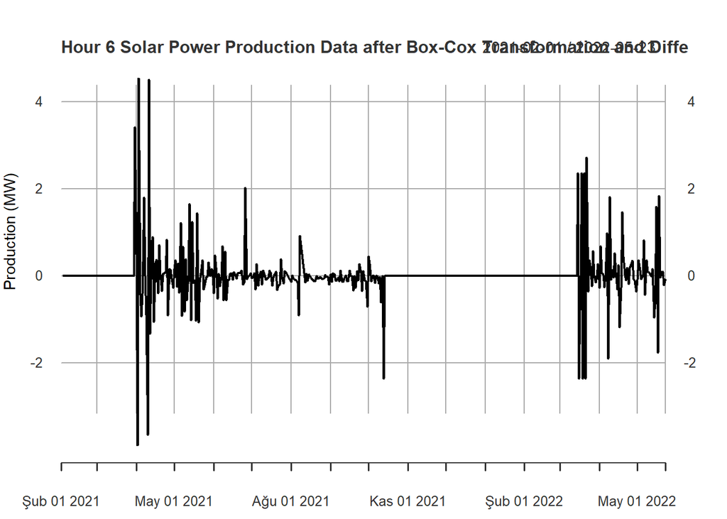

```
##
##  Fitting models using approximations to speed things up...
##
##  ARIMA(2,1,2) with drift         : 736.9504
##  ARIMA(0,1,0) with drift         : 915.1119
##  ARIMA(1,1,0) with drift         : 778.1501
##  ARIMA(0,1,1) with drift         : 751.6999
##  ARIMA(0,1,0)                    : 913.3553
##  ARIMA(1,1,2) with drift         : 736.2406
##  ARIMA(0,1,2) with drift         : 736.2598
##  ARIMA(1,1,1) with drift         : 743.3571
##  ARIMA(1,1,3) with drift         : 737.011
##  ARIMA(0,1,3) with drift         : 734.1502
##  ARIMA(0,1,4) with drift         : 735.8316
##  ARIMA(1,1,4) with drift         : 738.8188
##  ARIMA(0,1,3)                    : 733.378
##  ARIMA(0,1,2)                    : 735.719
##  ARIMA(1,1,3)                    : 736.2573
##  ARIMA(0,1,4)                    : 735.114
##  ARIMA(1,1,2)                    : 735.4704
##  ARIMA(1,1,4)                    : 738.1113
##
##  Now re-fitting the best model(s) without approximations...
##
##  ARIMA(0,1,3)                    : 732.9876
##
##  Best model: ARIMA(0,1,3)
```

```
## Series: box_6
## ARIMA(0,1,3)
##
## Coefficients:
##           ma1     ma2     ma3
##       -0.6716  0.1434  0.0913
## s.e.   0.0461  0.0560  0.0440
##
## sigma^2 = 0.2752:  log likelihood = -362.45
## AIC=732.9   AICc=732.99   BIC=749.51
```

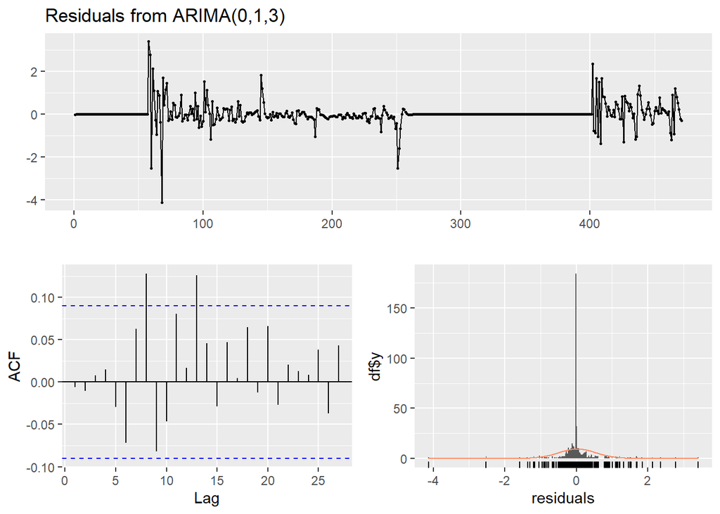

```
##
##  Ljung-Box test
##
## data:  Residuals from ARIMA(0,1,3)
## Q* = 17.088, df = 7, p-value = 0.01684
##
## Model df: 3.   Total lags used: 10
```

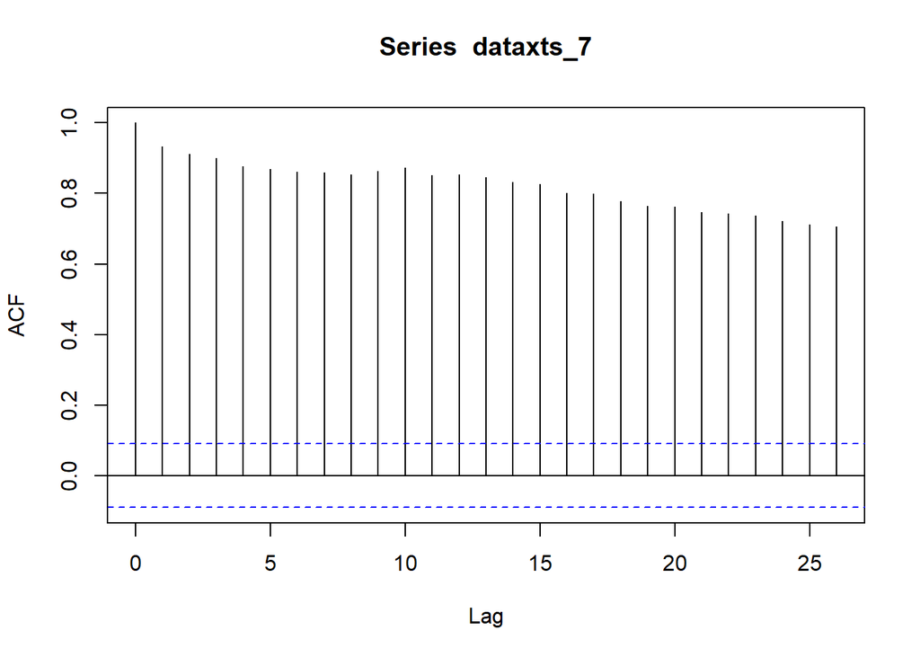

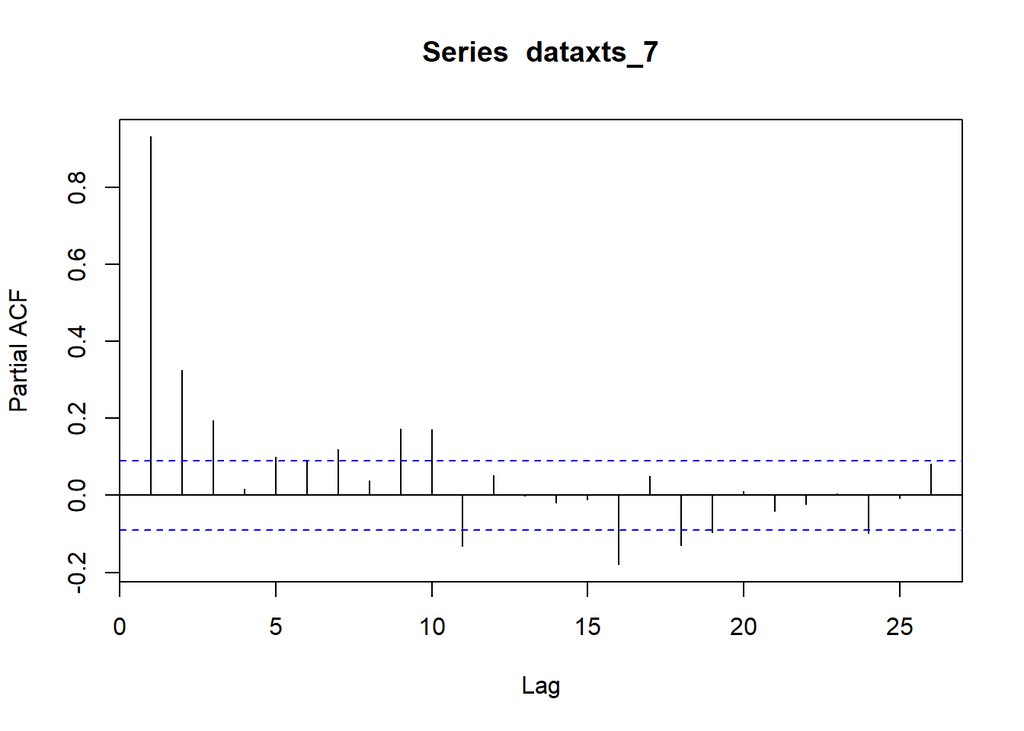

```
##
## #######################
## # KPSS Unit Root Test #
## #######################
##
## Test is of type: mu with 5 lags.
##
## Value of test-statistic is: 1.083
##
## Critical value for a significance level of:
##                 10pct  5pct 2.5pct  1pct
## critical values 0.347 0.463  0.574 0.739
```

```
##
## #######################
## # KPSS Unit Root Test #
## #######################
##
## Test is of type: mu with 5 lags.
##
## Value of test-statistic is: 0.9048
##
## Critical value for a significance level of:
##                 10pct  5pct 2.5pct  1pct
## critical values 0.347 0.463  0.574 0.739
```

```
##
## #######################
## # KPSS Unit Root Test #
## #######################
##
## Test is of type: mu with 5 lags.
##
## Value of test-statistic is: 0.1328
##
## Critical value for a significance level of:
##                 10pct  5pct 2.5pct  1pct
## critical values 0.347 0.463  0.574 0.739
```

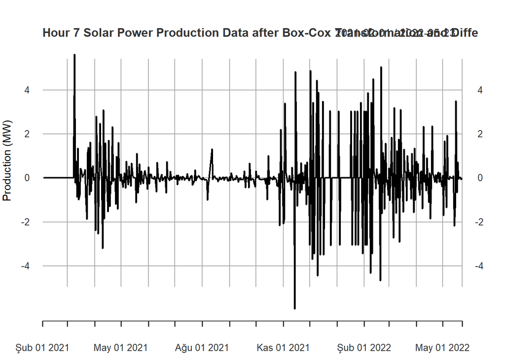

```
##
##  Fitting models using approximations to speed things up...
##
##  ARIMA(2,1,2) with drift         : Inf
##  ARIMA(0,1,0) with drift         : 1587.434
##  ARIMA(1,1,0) with drift         : 1463.633
##  ARIMA(0,1,1) with drift         : 1393.564
##  ARIMA(0,1,0)                    : 1585.545
##  ARIMA(1,1,1) with drift         : 1395.924
##  ARIMA(0,1,2) with drift         : 1394.893
##  ARIMA(1,1,2) with drift         : 1397.273
##  ARIMA(0,1,1)                    : 1393.514
##  ARIMA(1,1,1)                    : 1395.783
##  ARIMA(0,1,2)                    : 1394.739
##  ARIMA(1,1,0)                    : 1461.976
##  ARIMA(1,1,2)                    : 1397.153
##
##  Now re-fitting the best model(s) without approximations...
##
##  ARIMA(0,1,1)                    : 1394.681
##
##  Best model: ARIMA(0,1,1)
```

```
## Series: box_7
## ARIMA(0,1,1)
##
## Coefficients:
##           ma1
##       -0.6851
## s.e.   0.0303
##
## sigma^2 = 1.129:  log likelihood = -695.33
## AIC=1394.66   AICc=1394.68   BIC=1402.96
```

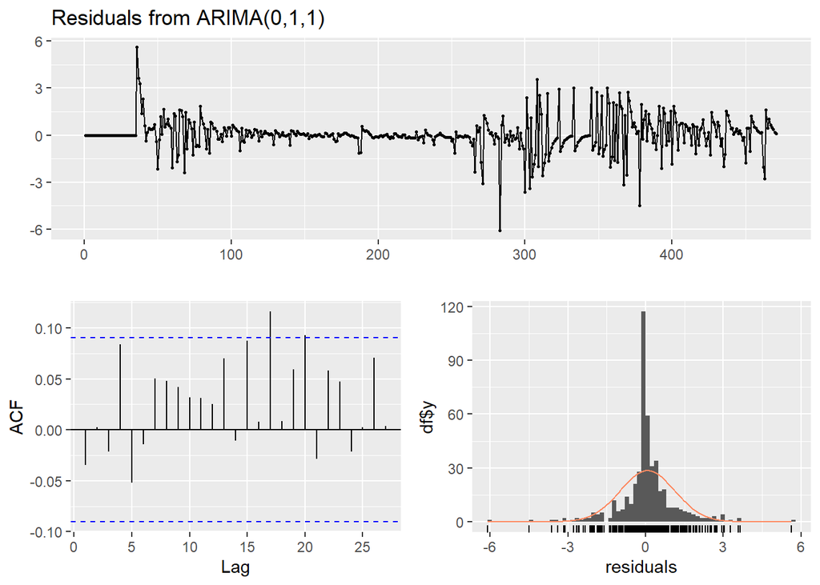

```
##
##  Ljung-Box test
##
## data:  Residuals from ARIMA(0,1,1)
## Q* = 9.1621, df = 9, p-value = 0.4224
##
## Model df: 1.   Total lags used: 10
```

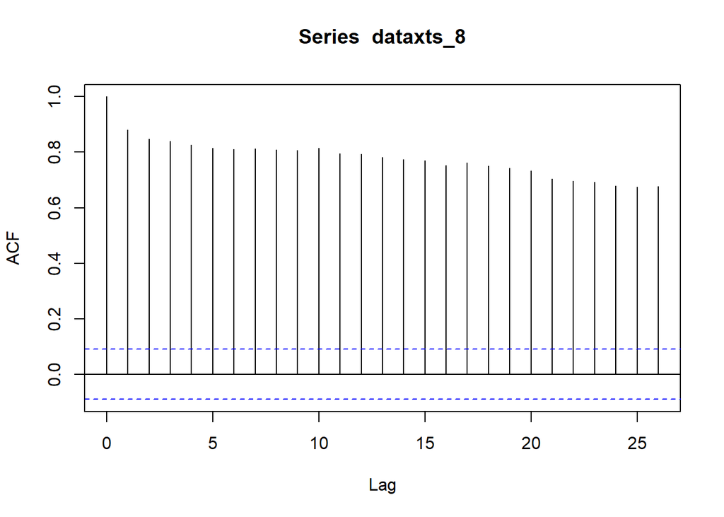

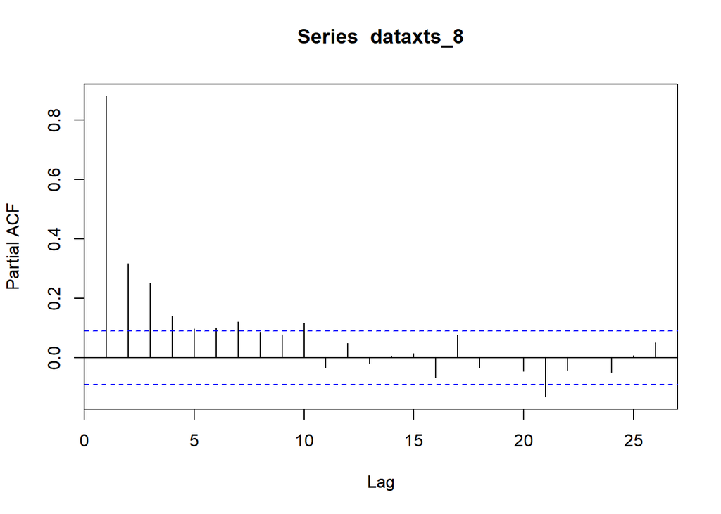

```
##
## #######################
## # KPSS Unit Root Test #
## #######################
##
## Test is of type: mu with 5 lags.
##
## Value of test-statistic is: 1.0167
##
## Critical value for a significance level of:
##                 10pct  5pct 2.5pct  1pct
## critical values 0.347 0.463  0.574 0.739
```

```
##
## #######################
## # KPSS Unit Root Test #
## #######################
##
## Test is of type: mu with 5 lags.
##
## Value of test-statistic is: 0.9526
##
## Critical value for a significance level of:
##                 10pct  5pct 2.5pct  1pct
## critical values 0.347 0.463  0.574 0.739
```

```
##
## #######################
## # KPSS Unit Root Test #
## #######################
##
## Test is of type: mu with 5 lags.
##
## Value of test-statistic is: 0.0522
##
## Critical value for a significance level of:
##                 10pct  5pct 2.5pct  1pct
## critical values 0.347 0.463  0.574 0.739
```

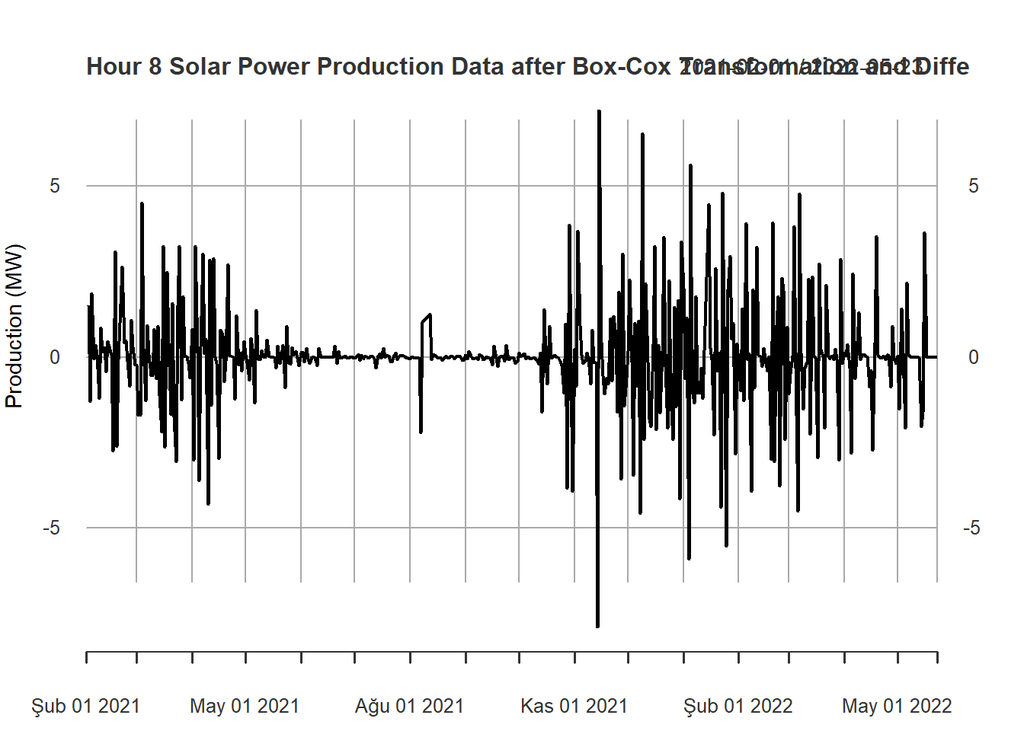

```
##
##  Fitting models using approximations to speed things up...
##
##  ARIMA(2,1,2) with drift         : 1568.287
##  ARIMA(0,1,0) with drift         : 1770.854
##  ARIMA(1,1,0) with drift         : 1675.873
##  ARIMA(0,1,1) with drift         : 1567.355
##  ARIMA(0,1,0)                    : 1768.881
##  ARIMA(1,1,1) with drift         : 1562.04
##  ARIMA(2,1,1) with drift         : 1570.005
##  ARIMA(1,1,2) with drift         : 1564.038
##  ARIMA(0,1,2) with drift         : 1566.24
##  ARIMA(2,1,0) with drift         : 1636.356
##  ARIMA(1,1,1)                    : 1561.31
##  ARIMA(0,1,1)                    : 1566.795
##  ARIMA(1,1,0)                    : 1673.93
##  ARIMA(2,1,1)                    : 1569.402
##  ARIMA(1,1,2)                    : 1563.326
##  ARIMA(0,1,2)                    : 1565.774
##  ARIMA(2,1,0)                    : 1634.499
##  ARIMA(2,1,2)                    : 1567.657
##
##  Now re-fitting the best model(s) without approximations...
##
##  ARIMA(1,1,1)                    : 1564.259
##
##  Best model: ARIMA(1,1,1)
```

```
## Series: box_8
## ARIMA(1,1,1)
##
## Coefficients:
##          ar1      ma1
##       0.0924  -0.8412
## s.e.  0.0530   0.0247
##
## sigma^2 = 1.615:  log likelihood = -779.1
## AIC=1564.21   AICc=1564.26   BIC=1576.67
```

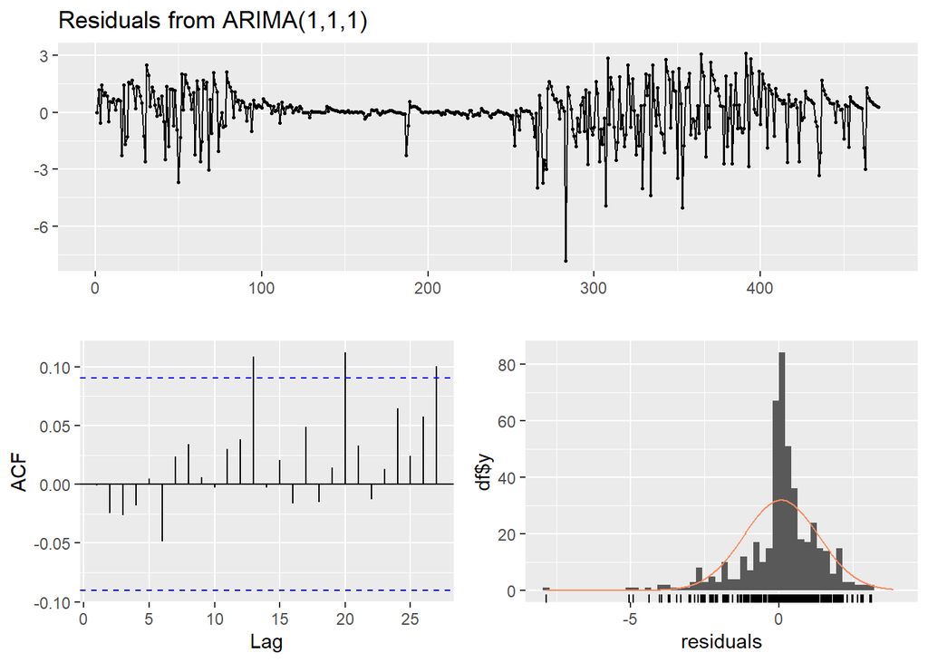

```
##
##  Ljung-Box test
##
## data:  Residuals from ARIMA(1,1,1)
## Q* = 2.7709, df = 8, p-value = 0.9479
##
## Model df: 2.   Total lags used: 10
```

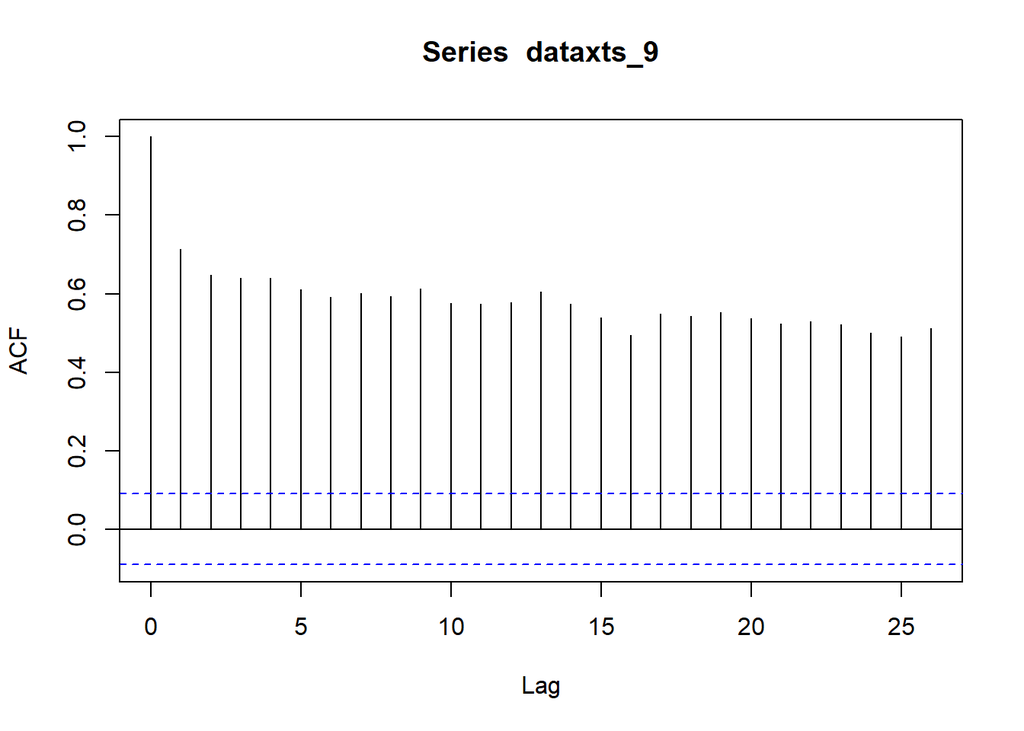

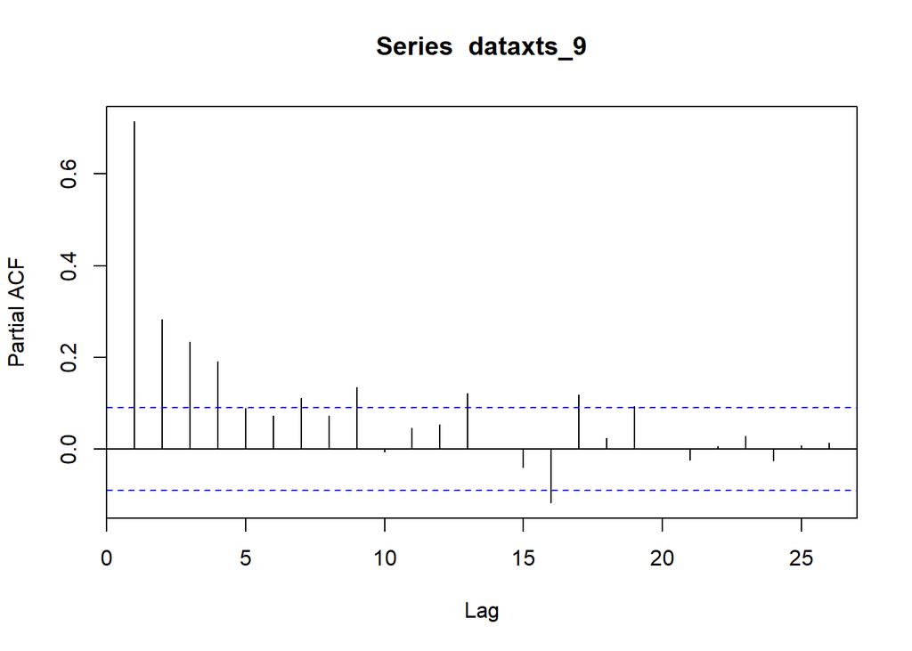

```
##
## #######################
## # KPSS Unit Root Test #
## #######################
##
## Test is of type: mu with 5 lags.
##
## Value of test-statistic is: 0.9946
##
## Critical value for a significance level of:
##                 10pct  5pct 2.5pct  1pct
## critical values 0.347 0.463  0.574 0.739
```

```
##
## #######################
## # KPSS Unit Root Test #
## #######################
##
## Test is of type: mu with 5 lags.
##
## Value of test-statistic is: 0.8886
##
## Critical value for a significance level of:
##                 10pct  5pct 2.5pct  1pct
## critical values 0.347 0.463  0.574 0.739
```

```
##
## #######################
## # KPSS Unit Root Test #
## #######################
##
## Test is of type: mu with 5 lags.
##
## Value of test-statistic is: 0.0284
##
## Critical value for a significance level of:
##                 10pct  5pct 2.5pct  1pct
## critical values 0.347 0.463  0.574 0.739
```

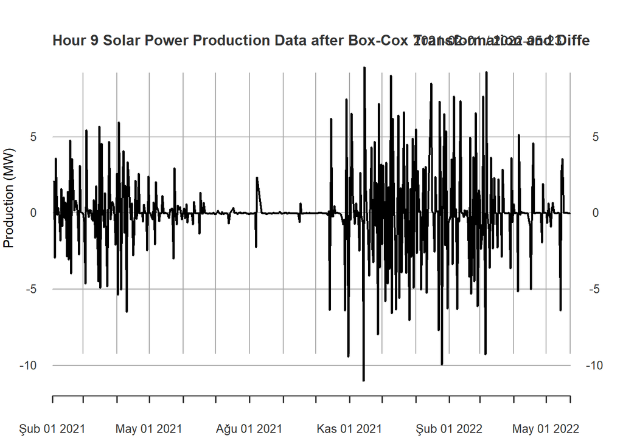

```
##
##  Fitting models using approximations to speed things up...
##
##  ARIMA(2,1,2) with drift         : 2061.532
##  ARIMA(0,1,0) with drift         : 2260.598
##  ARIMA(1,1,0) with drift         : 2171.509
##  ARIMA(0,1,1) with drift         : 2062.995
##  ARIMA(0,1,0)                    : 2258.605
##  ARIMA(1,1,2) with drift         : 2056.79
##  ARIMA(0,1,2) with drift         : 2057.237
##  ARIMA(1,1,1) with drift         : 2054.791
##  ARIMA(2,1,1) with drift         : 2065.898
##  ARIMA(2,1,0) with drift         : 2131.908
##  ARIMA(1,1,1)                    : 2053.86
##  ARIMA(0,1,1)                    : 2062.12
##  ARIMA(1,1,0)                    : 2169.524
##  ARIMA(2,1,1)                    : 2065.167
##  ARIMA(1,1,2)                    : 2055.87
##  ARIMA(0,1,2)                    : 2056.58
##  ARIMA(2,1,0)                    : 2129.977
##  ARIMA(2,1,2)                    : 2060.809
##
##  Now re-fitting the best model(s) without approximations...
##
##  ARIMA(1,1,1)                    : 2057.127
##
##  Best model: ARIMA(1,1,1)
```

```
## Series: box_9
## ARIMA(1,1,1)
##
## Coefficients:
##          ar1      ma1
##       0.1474  -0.8863
## s.e.  0.0516   0.0216
##
## sigma^2 = 4.607:  log likelihood = -1025.54
## AIC=2057.08   AICc=2057.13   BIC=2069.53
```

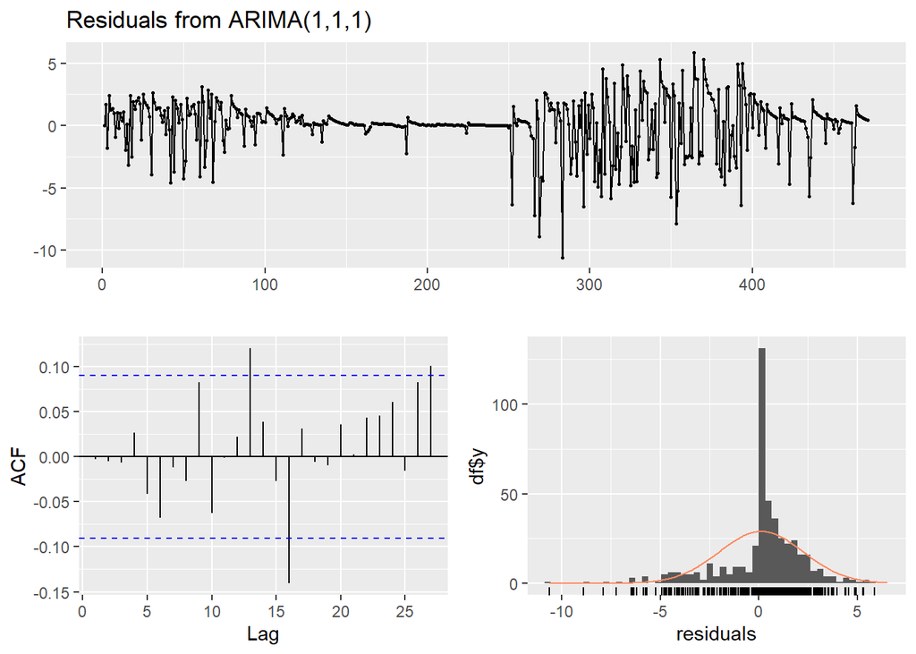

```
##
##  Ljung-Box test
##
## data:  Residuals from ARIMA(1,1,1)
## Q* = 8.9829, df = 8, p-value = 0.3437
##
## Model df: 2.   Total lags used: 10
```